# Weighted Nearest Neighbor Analysis

- Show All Code
- Hide All Code
- View Source

Author

TigerZ

Published

2023-11-04

多模态的同时测量，称为多模态分析，代表了单细胞基因组学的一个令人兴奋的前沿领域，并且需要能够基于多种数据类型定义细胞状态的新计算方法。每种模态的信息内容不同，甚至在同一数据集中的细胞之间也是如此，这对多模态数据集的分析和整合来说是一个紧迫的挑战。在([Hao*, Hao* et al, Cell 2021](https://doi.org/10.1016/j.cell.2021.04.048))中，我们引入了 ‘weighted-nearest neighbor’ (WNN) 分析，这是一种无监督框架，用于学习每个细胞中每种数据类型的相对效用，从而实现多种模态的整合分析。

本小节介绍了用于分析多模态单细胞数据集的 WNN 工作流程。工作流程由三个步骤组成：

- 每种模态单独进行独立预处理和降维
- 学习细胞-特异性模态“权重”，并构建一个 WNN graph 整合模态
- WNN graph 的下游分析（即，可视化、聚类等）

我们演示了 WNN 分析在两种单细胞多模态技术中的应用：CITE-seq 和 10x multiome。我们根据两种模态而不是任何一种单独的模态来定义细胞状态。

## WNN analysis of CITE-seq, RNA + ADT

我们使用来自 (Stuart*, Butler* et al, Cell 2019) 的 CITE-seq 数据集，该数据集包含 30,672 个 scRNA-seq 谱，与一组来自骨髓的 25 种抗体一起测量。该对象包含两种 assays：RNA 和 antibody-derived tags (ADT)。

要运行此小节，请安装 [CRAN](https://cran.r-project.org/web/packages/Seurat/index.html) 上提供的 Seurat v4 和 [GitHub](https://github.com/satijalab/seurat-data) 上提供的 SeuratData。

```r
#install.packages("Seurat")
```

```r
library(Seurat)
library(SeuratData)
library(cowplot)
library(dplyr)
```

```r
#InstallData("bmcite")
bm <- LoadData(ds = "bmcite")
```

我们首先对两种 assays 独立进行预处理和降维。我们使用标准 normalization，但您也可以使用 SCTransform 或任何替代方法。

```r
DefaultAssay(bm) <- 'RNA'
bm <- NormalizeData(bm) %>% FindVariableFeatures() %>% ScaleData() %>% RunPCA()
```

```
PC_ 1
Positive:  TRBC1, LAT, CD8B, CCL5, KLRB1, IGKC, S100A12, GZMA, S100A8, S100A9
       MS4A1, S100B, GNLY, CST7, TYROBP, KLRD1, RP11-291B21.2, NKG7, VCAN, CD14
       IGLC2, CCL4, AC092580.4, FCN1, IGLC3, PRF1, RBP7, SERPINA1, DUSP2, JUN
Negative:  KIAA0101, TYMS, KLF1, KCNH2, FAM178B, APOC1, CNRIP1, CENPU, GATA1, BIRC5
       CENPF, EPCAM, CKS2, RP11-620J15.3, TUBA1B, TFR2, CA1, HMGA1, STMN1, HIST1H4C
       CDT1, AHSP, TOP2A, TK1, GFI1B, TUBB, MKI67, NME4, SMIM1, TMEM56
PC_ 2
Positive:  RPL3, RPS3, RPS18, RPS5, RPS4X, RPSA, RPS12, RPS23, RPS2, EEF1B2
       RPL4, LDHB, NPM1, RPS17, RPLP0, TRBC1, LAT, RPL7A, GYPC, HSPA8
       CD8B, KLRB1, CCL5, HNRNPA1, PEBP1, RPL37A, MYC, NUCB2, SOD1, CD79A
Negative:  LYZ, FCN1, CST3, TYROBP, S100A9, LST1, S100A8, CSTA, MNDA, VCAN
       LGALS1, AIF1, S100A12, CFD, SERPINA1, FCER1G, MS4A6A, FOS, S100A6, CD14
       LGALS2, FTH1, GAPDH, ANXA2, CD36, CPVL, RBP7, HLA-DRA, LINC01272, H3F3A
PC_ 3
Positive:  CD74, HLA-DRA, HLA-DPB1, HLA-DPA1, IGLL1, ITM2C, SMIM24, RPS23, FABP5, HLA-DRB5
       TCF4, RPS18, PLD4, HLA-DQA1, RPS4X, SOX4, SPINK2, RPLP1, KIAA0125, HLA-DQB1
       HLA-DRB1, RPS2, PRSS57, IRF8, CDCA7, C1QTNF4, STMN1, BCL11A, NREP, RPS24
Negative:  GYPA, ALAS2, SLC4A1, AHSP, HBM, GYPB, CA2, HBD, RHAG, CA1
       HBA1, TMEM56, SELENBP1, HBB, HBA2, MYL4, HEMGN, HMBS, RHCE, HBQ1
       DMTN, RFESD, SPTA1, FECH, KLF1, ANK1, CTSE, SMIM1, TSPO2, SLC25A37
PC_ 4
Positive:  CD79A, MS4A1, CD79B, CD74, HLA-DRA, HLA-DPB1, HLA-DPA1, IGHD, HLA-DQA1, HLA-DQB1
       BANK1, VPREB3, SPIB, TCL1A, HLA-DRB5, FAM129C, LINC00926, IGHM, IGKC, HLA-DRB1
       TNFRSF13C, JCHAIN, TSPAN13, IRF8, FCER2, CD24, BLK, CD22, GNG7, FCRLA
Negative:  NKG7, CST7, PRSS57, GNLY, GZMA, KLRB1, CCL5, LDHB, KLRD1, CMC1
       CYTL1, PRF1, EGFL7, LYAR, TRBC1, KLRF1, GAPDH, S100A6, NGFRAP1, LAT
       RPS3, S100B, FGFBP2, GZMH, GATA2, RPS24, NPW, CCL4, SMIM24, CDK6
PC_ 5
Positive:  RPS2, RPS18, RPS12, RPS23, RPL37A, RPLP1, RPL4, RPS5, RPS4X, CNRIP1
       RPS17, APOC1, NPM1, MYC, EEF1B2, FAM178B, EPCAM, KCNH2, KLF1, RPLP0
       RPL7A, CYTL1, MS4A1, LDHB, SMIM10, GATA1, APOE, RPS3, TFR2, RPL3
Negative:  NKG7, GZMB, CST7, GNLY, GZMA, KLRD1, CMC1, KLRF1, PRF1, CCL4
       CCL5, GZMH, CLIC3, FGFBP2, SPON2, C12orf75, TRDC, KLRB1, HOPX, XCL2
       CD160, IL2RB, PLAC8, FCGR3A, TRGC2, KLRG1, DUSP2, RHOC, PLEK, LAIR2
```

```r
DefaultAssay(bm) <- 'ADT'
# we will use all ADT features for dimensional reduction
# we set a dimensional reduction name to avoid overwriting the
VariableFeatures(bm) <- rownames(bm[["ADT"]])
bm <- NormalizeData(bm, normalization.method = 'CLR', margin = 2) %>%
  ScaleData() %>% RunPCA(reduction.name = 'apca')
```

```
Normalizing across cells
```

```
PC_ 1
Positive:  CD3, CD28, CD27, CD127-IL7Ra, CD278-ICOS, CD4, CD8a, CD161, CD25, CD45RO
       CD45RA, CD197-CCR7
Negative:  HLA.DR, CD11c, CD14, CD38, CD69, CD123, CD11a, CD34, CD19, CD79b
       CD16, CD56
PC_ 2
Positive:  CD45RO, CD11a, CD14, CD4, CD11c, CD28, CD3, CD69, CD278-ICOS, CD127-IL7Ra
       CD38, CD161
Negative:  CD45RA, CD19, CD79b, CD197-CCR7, CD8a, CD57, CD56, CD16, CD27, CD25
       HLA.DR, CD34
PC_ 3
Positive:  CD16, CD56, CD8a, CD11a, CD57, CD161, CD45RA, CD38, CD3, CD127-IL7Ra
       CD27, CD11c
Negative:  CD19, CD79b, CD4, CD25, HLA.DR, CD197-CCR7, CD69, CD34, CD28, CD45RO
       CD14, CD278-ICOS
PC_ 4
Positive:  CD161, CD25, CD45RO, CD56, CD16, CD4, CD79b, CD19, CD28, CD57
       CD127-IL7Ra, HLA.DR
Negative:  CD8a, CD27, CD14, CD45RA, CD3, CD11c, CD69, CD38, CD197-CCR7, CD11a
       CD34, CD123
PC_ 5
Positive:  CD4, CD38, CD123, CD16, CD34, CD45RA, CD56, CD278-ICOS, CD28, CD197-CCR7
       CD27, CD3
Negative:  CD45RO, CD8a, CD69, CD161, CD79b, CD19, CD25, CD57, CD14, CD11a
       CD127-IL7Ra, HLA.DR
```

对于每个细胞，我们根据 RNA 和 protein 相似性的加权组合计算数据集中其最近的邻居。细胞特定模态权重和多模态邻居在单个函数中计算，在该数据集上运行大约需要 2 分钟。我们指定每种模态的维度（类似于指定 scRNA-seq 聚类中包含的 PCs 数量），但您可以改变这些设置，以查看微小的变化对整体结果的影响最小。

```r
# 识别多模态邻居。这些将被存储在 neighbors slot 中，
# 并且可以使用 bm[['weighted.nn']] 访问
# WNN graph 可以通过 bm[["wknn"]] 访问，
# 并且用于聚类的 SNN graph 在 bm[["wsnn"]] 中
# 细胞特异性模态权重可以通过 bm$RNA.weight 访问
bm <- FindMultiModalNeighbors(
  bm, reduction.list = list("pca", "apca"),
  dims.list = list(1:30, 1:18), modality.weight.name = "RNA.weight"
)
```

```
Calculating cell-specific modality weights
```

```
Finding 20 nearest neighbors for each modality.
```

```
Calculating kernel bandwidths
```

```
Finding multimodal neighbors
```

```
Constructing multimodal KNN graph
```

```
Constructing multimodal SNN graph
```

我们现在可以使用这些结果进行下游分析，例如可视化和聚类。例如，我们可以基于 RNA 和 protein 数据的加权组合创建数据的 UMAP 可视化。我们还可以执行 graph-based 聚类，并在 UMAP 上可视化这些结果以及一组细胞注释。

```r
bm <- RunUMAP(bm, nn.name = "weighted.nn", reduction.name = "wnn.umap", reduction.key = "wnnUMAP_")
bm <- FindClusters(bm, graph.name = "wsnn", algorithm = 3, resolution = 2, verbose = FALSE)
```

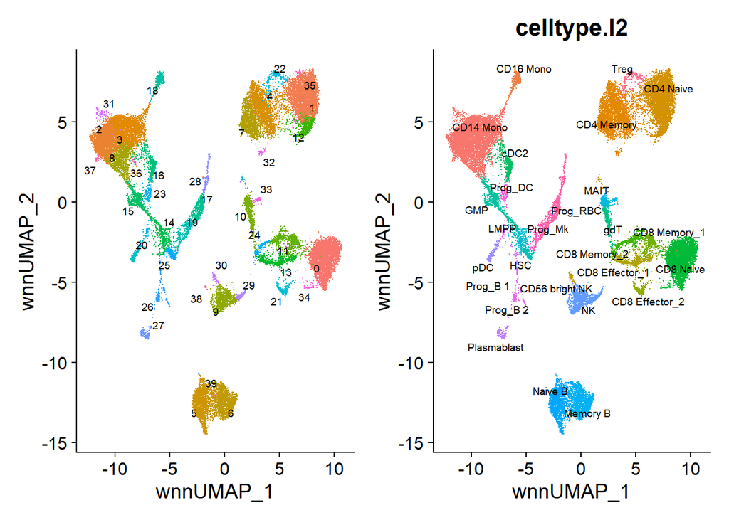

```r
p1 <- DimPlot(bm, reduction = 'wnn.umap', label = TRUE, repel = TRUE, label.size = 2.5) + NoLegend()
p2 <- DimPlot(bm, reduction = 'wnn.umap', group.by = 'celltype.l2', label = TRUE, repel = TRUE, label.size = 2.5) + NoLegend()
p1 + p2
```

我们还可以仅基于 RNA 和 protein 数据计算 UMAP 可视化并进行比较。我们发现，在识别祖细胞状态方面，RNA 分析比 ADT 分析提供更多信息（ADT panel 包含分化细胞的标记），而 T 细胞状态则相反（ADT 分析优于 RNA）。

```r
bm <- RunUMAP(bm, reduction = 'pca', dims = 1:30, assay = 'RNA',
              reduction.name = 'rna.umap', reduction.key = 'rnaUMAP_')
bm <- RunUMAP(bm, reduction = 'apca', dims = 1:18, assay = 'ADT',
              reduction.name = 'adt.umap', reduction.key = 'adtUMAP_')
```

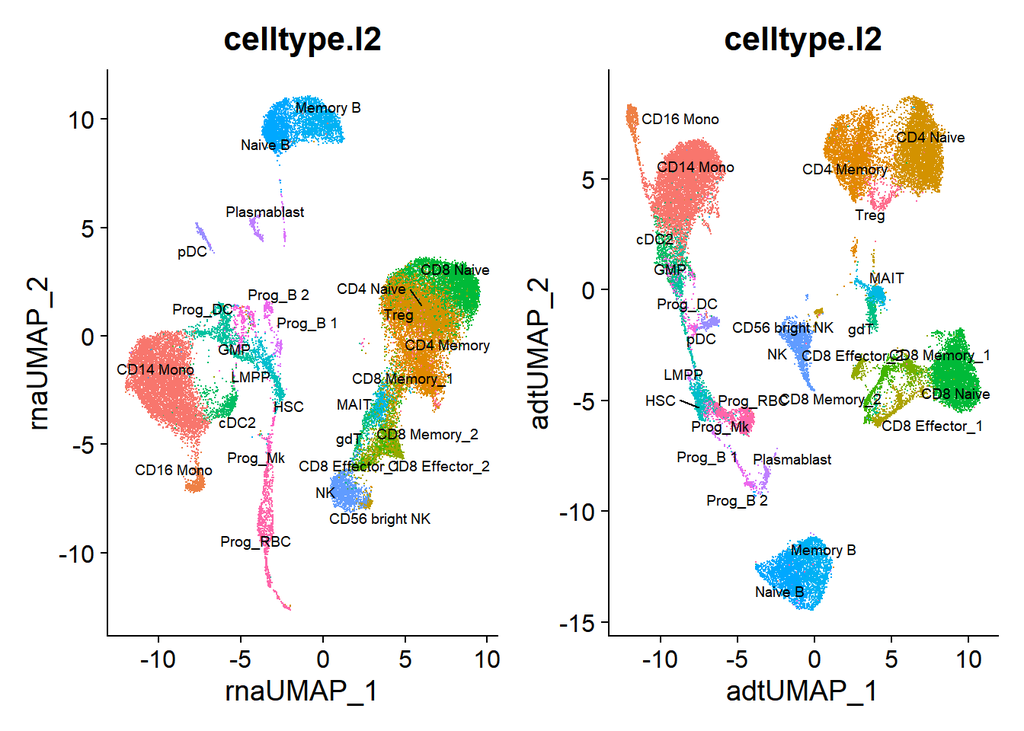

```r
p3 <- DimPlot(bm, reduction = 'rna.umap', group.by = 'celltype.l2', label = TRUE,
              repel = TRUE, label.size = 2.5) + NoLegend()
p4 <- DimPlot(bm, reduction = 'adt.umap', group.by = 'celltype.l2', label = TRUE,
              repel = TRUE, label.size = 2.5) + NoLegend()
p3 + p4
```

我们可以在多模态 UMAP 上可视化规范标记基因和蛋白质的表达，这可以帮助验证所提供的注释：

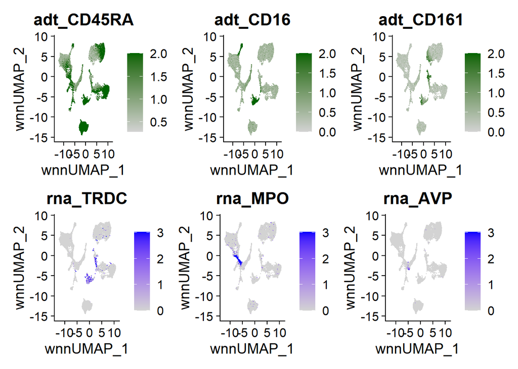

```r
p5 <- FeaturePlot(bm, features = c("adt_CD45RA","adt_CD16","adt_CD161"),
                  reduction = 'wnn.umap', max.cutoff = 2,
                  cols = c("lightgrey","darkgreen"), ncol = 3)
p6 <- FeaturePlot(bm, features = c("rna_TRDC","rna_MPO","rna_AVP"),
                  reduction = 'wnn.umap', max.cutoff = 3, ncol = 3)
p5 / p6
```

最后，我们可以可视化为每个细胞学习的模态权重。每个具有最高 RNA 权重的群体代表祖细胞，而具有最高 protein 权重的群体代表 T 细胞。这符合我们的生物学预期，因为抗体组不包含可以区分不同祖细胞群的标记。

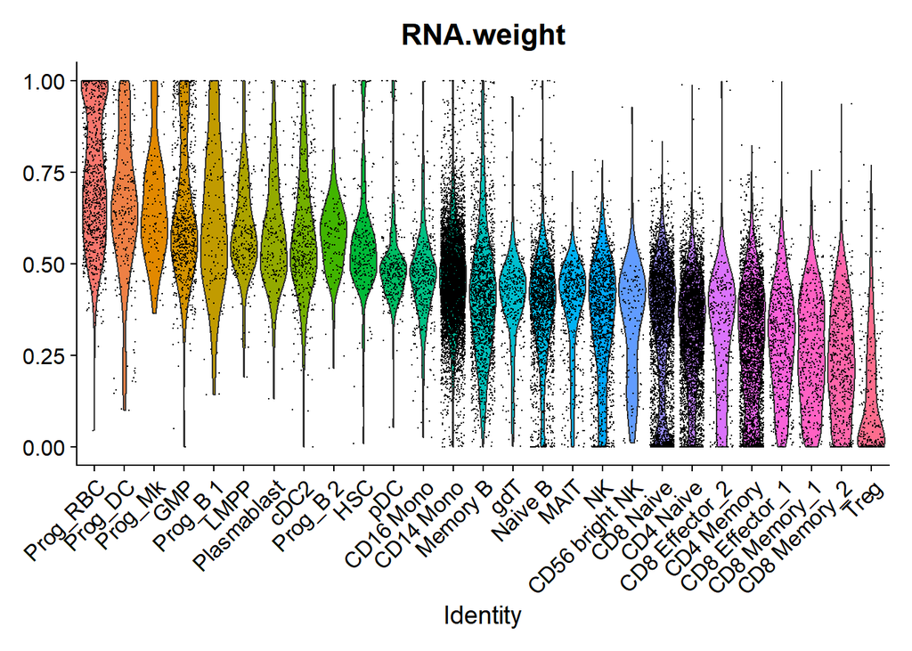

```r
 VlnPlot(bm, features = "RNA.weight", group.by = 'celltype.l2', sort = TRUE, pt.size = 0.1) +
  NoLegend()
```